# Week 5, Day 1, Homework

# Load Libraries

```r
library(tidyverse)
library(janitor)
library(scales)
```

# Read In Data

```r
qb_revenue_breakdown <- clean_names(CodeClanData::qb_revenue_breakdown)
qb_monthly_sales <- clean_names(CodeClanData::qb_monthly_sales)
qb_competitors <- clean_names(CodeClanData::qb_competitors)
qb_device_data <- CodeClanData::qb_device_data
```

# NOTES ADDED AFTER REVIEW

```r
# Basic Structure

df %>%
  ggplot() +
  geom_col() +
  theme_light() + # Set Base R Theme
  theme(plot.title = element_text(size = "", face = ""), # Set Title Size & Face
        plot.subtitle = element_text(size = ""), # Set Subtitle Size & Face
        legend.title = element_text(size = "", face = ""), # Set Legend Size & Face
        axis.title.x = element_text(size = ""), # Set x-axis Size & Face
        axis.title.y = element_text(size = ""), # Set y-axis Size & Face
        panel.grid = element_line(colour = "", linetype = "")) # Set grid Attributes
  labs(
    x = "\n", # Set x-axis Label
    y = "\n", # Set y-axis Label
    title = "", # Set Plot Title
    subtitle = "", # Set Plot Subtitle
    fill = "")

# Other Useful Styling/Formatting Functions
scale_y_continuous(labels = scales::dollar_format(prefix = "£")) # Set y-axis to £ format.
scale_fill_manual(values = "") # Set fill values, either a vector or named.
scale_x_date(date_labels = "%b %y", date_breaks = "1 month") # Format dates on x-axis.
axis.text.x = element_text(angle = 45, vjust = 0.5) # Rotate x-axis ticks labels.
col_scheme <- c("#E89FE9", "#50434F", "#B6A7B5", "#F9A472", "#BD7040") # Define a colour scheme.

# Useful Case Examples
geom_line(colour = col_scheme[3]) # Set the line to index 3 of colour scheme
```

# MVP

## Part 1

### Q1.

Take the data in the dataset qb_revenue_breakdown and make a stacked bar chart showing the sources of revenue across the two years in the dataset.

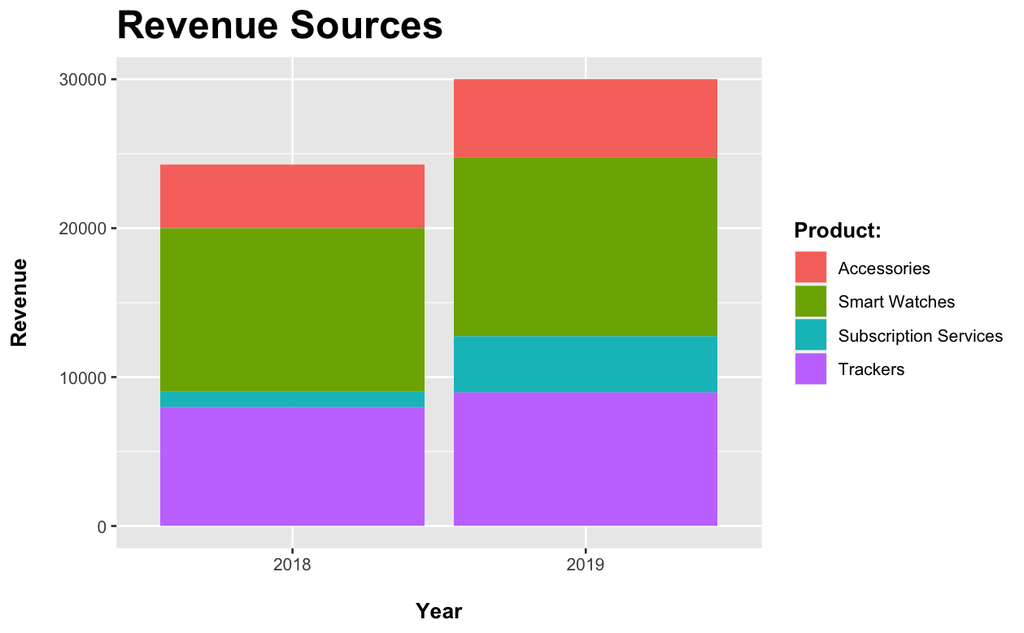

```r
qb_revenue_breakdown %>%
  ggplot(aes(x = year, y = revenue, fill = product)) +
  geom_col() +
    labs(
    x = "\nYear",
    y = "Revenue\n",
    title = "Revenue Sources",
    fill = "Product:"
  ) +
  theme(title = element_text(face = "bold"),
        plot.title = element_text(size = 20))
```

### Q2.

Make a line chart showing monthly sales of the “flagship product” - the ‘KwikBit Unit 1’ - over the last year. This data is inside qb_monthly_sales, but you will need to use filter() or subset() (base R).

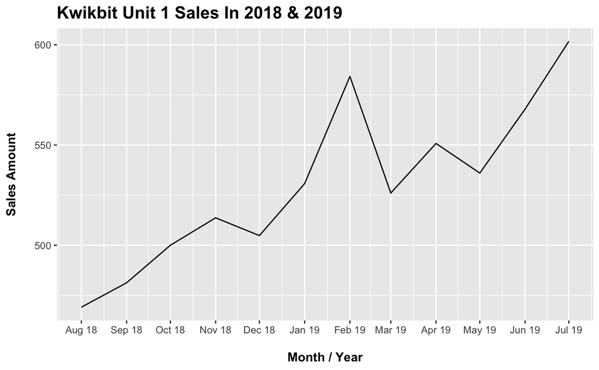

```r
qb_monthly_sales %>%
  filter(cashflow == "Kwikbit Unit 1 Sales") %>%
  ggplot(aes(x = date, y = amount)) +
  geom_line() +
  scale_x_date(date_labels = "%b %y", date_breaks = "1 month") +
  labs(
    x = "\nMonth / Year",
    y = "Sales Amount\n",
    title = "Kwikbit Unit 1 Sales In 2018 & 2019",
    fill = "Product:"
  ) +
  theme(title = element_text(face = "bold"),
        plot.title = element_text(size = 15))
```

### Q3.

Make a line chart showing monthly revenue and costs over the last year. This data is also in qb_monthly_sales.

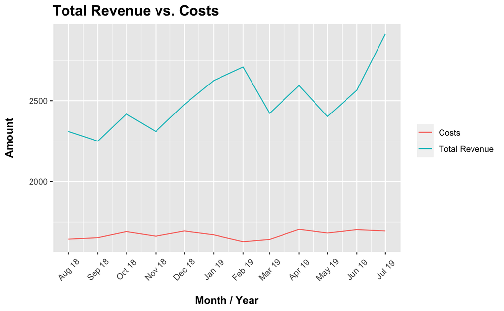

```r
qb_monthly_sales %>%
  filter(cashflow != "Kwikbit Unit 1 Sales") %>%
  ggplot(aes(x = date, y = amount, colour = cashflow )) +
  geom_line() +
  scale_x_date(date_labels = "%b %y", date_breaks = "1 month") +
  theme(axis.text.x = element_text(angle = 45, vjust = 0.5),
        title = element_text(face = "bold"),
        plot.title = element_text(size = 15),
        legend.title = element_blank()) +
  labs(
    x = "\nMonth / Year",
    y = "Amount\n",
    title = "Total Revenue vs. Costs",
  ) +
  scale_color_discrete(labels=c('Costs', 'Total Revenue'))
```

### Q4.

Show annual sales of personal fitness trackers over the last 5 years broken down by company as a ribbon plot (use geom_area). This data is in qb_competitors.

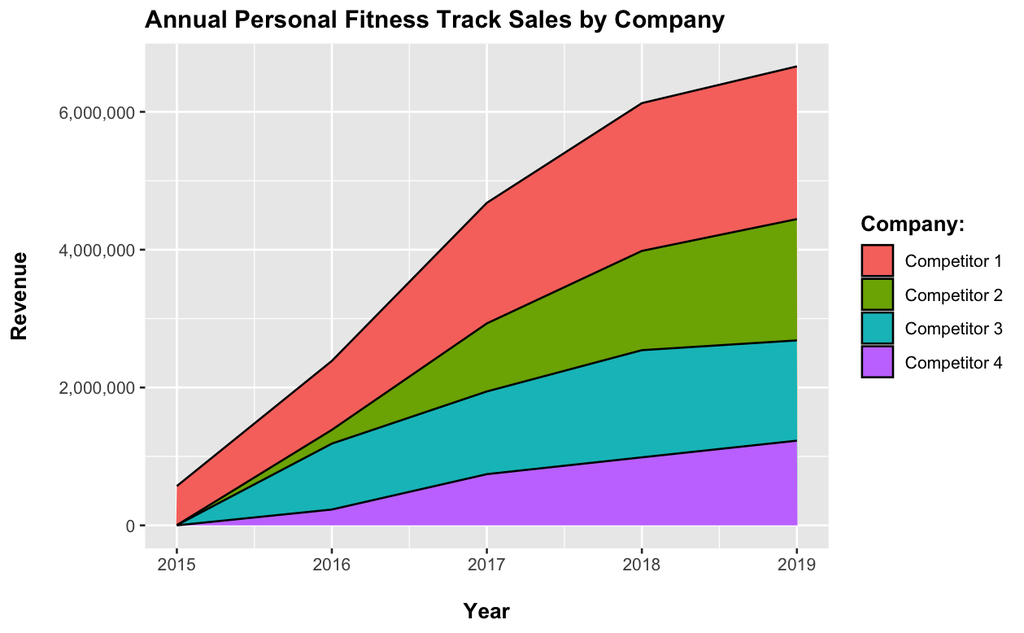

```r
qb_competitors %>%
  ggplot(aes(x = year, y = revenue, fill = company)) +
  geom_area(colour = "black") +
  scale_y_continuous(labels = comma) +
  theme(title = element_text(face = "bold"),
        plot.title = element_text(size = 12.5)) +
  labs(
    x = "\nYear",
    y = "Revenue\n",
    title = "Annual Personal Fitness Track Sales by Company",
    fill = "Company:"
  )
```

### Q5.

Now show the sales from the four competitors as a line graph. Include an extra layer that shows the data points used to make the lines.

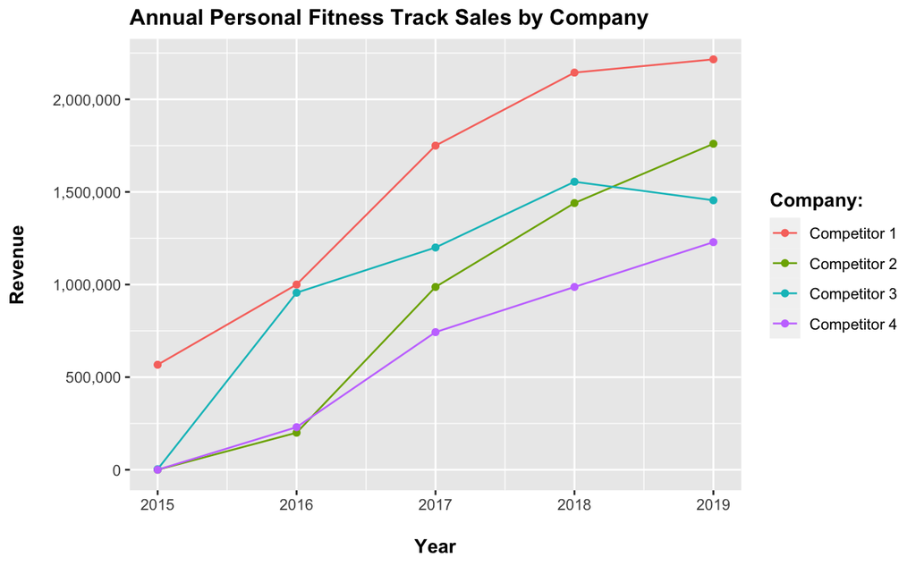

```r
qb_competitors %>%
  ggplot(aes(x = year, y = revenue, colour = company)) +
  geom_line() +
  geom_point() +
  scale_y_continuous(labels = comma) +
  theme(title = element_text(face = "bold"),
        plot.title = element_text(size = 12.5)) +
  labs(
    x = "\nYear",
    y = "Revenue\n",
    title = "Annual Personal Fitness Track Sales by Company",
    colour = "Company:"
  )
```

```r
NA
NA
```

### Q6.

Now the company wants to compare the number of steps that their device counts vs. their competitors. Make a line graph of the number of steps throughout time, and use faceting to compare between companies and people. The data for this is in qb_device_data.

```r
qb_device_data_updated <- qb_device_data %>%
  group_by(id, device) %>%
  mutate(rolling_steps_count = cumsum(counts),
         total_time_mins = (hours * 60) + mins)
```

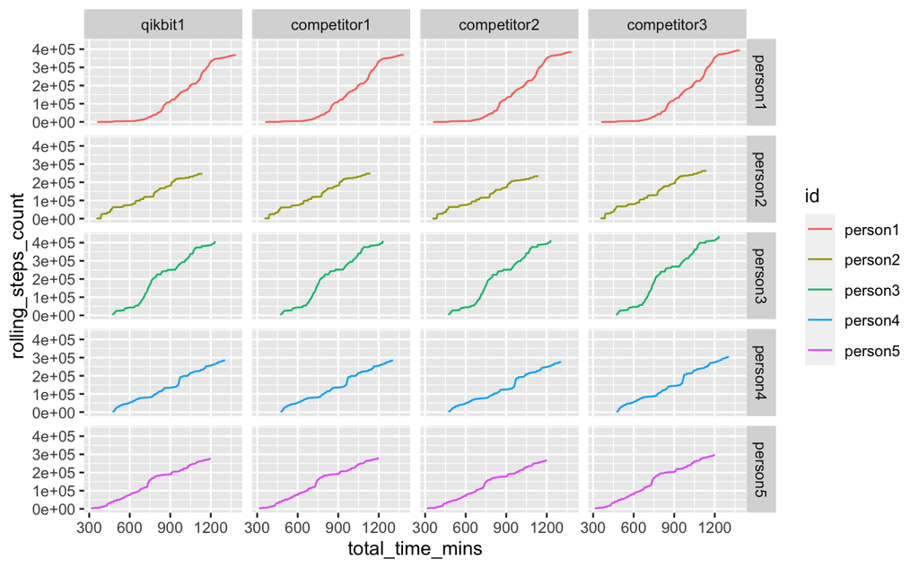

```r
qb_device_data_updated %>%
  group_by(id) %>%
  ggplot(aes(x = total_time_mins, y = rolling_steps_count, colour = id)) +
  geom_line() +
  facet_grid(id ~ device)
```

#### Update Following Homework Review

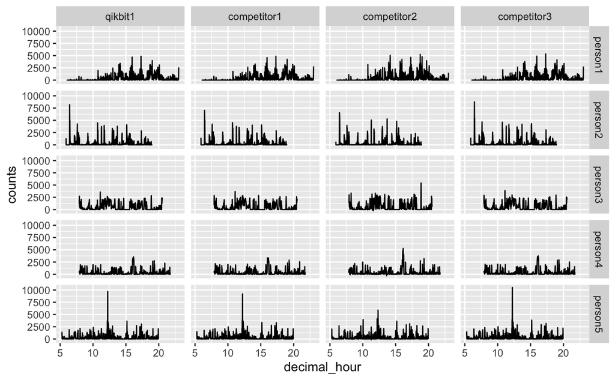

```r
qb_device_data_review <-
mutate(qb_device_data, decimal_hour = hours + (mins/60))

ggplot(qb_device_data_review) +
  aes(x = decimal_hour, y = counts) +
  geom_line() +
  facet_grid(id ~ device)
```

## Part 2

Take the plots that you produced in part one and now polish them by:

1. Adding appropriate labels
2. hanging the scales and coordinates when appropriate.
3. Applying a unified theme, which is described below:
- Graphs should have white backgrounds, and use colour sparingly.
- There should be faint grid lines.
- Font sizes should be ~12pt although titles should be slightly larger and axis labels can be slightly smaller.
- All plots should use colours from the following company colour scheme.

### Q1 Revised

```r
col_scheme <- c("#E89FE9", "#50434F", "#B6A7B5", "#F9A472", "#BD7040")
```

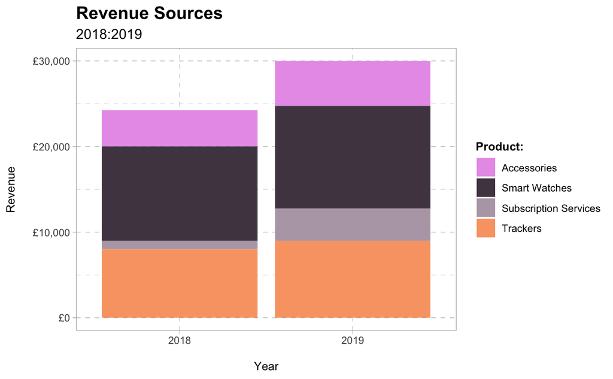

```r
qb_revenue_breakdown %>%
  ggplot(aes(x = year, y = revenue, fill = product)) +
  geom_col() +
  theme_light() +
  theme(plot.title = element_text(size = 15, face = "bold"),
        plot.subtitle = element_text(size = 12),
        legend.title = element_text(size = 10, face = "bold"),
        axis.title.x = element_text(size = 10),
        axis.title.y = element_text(size = 10),
        panel.grid = element_line(colour = "grey", linetype = "dashed")) +
  labs(
    x = "\nYear",
    y = "Revenue\n",
    title = "Revenue Sources",
    subtitle = "2018:2019",
    fill = "Product:"
  ) +
  scale_y_continuous(labels = scales::dollar_format(prefix = "£")) +
  scale_fill_manual(values = col_scheme)
```

### Q2 Revised

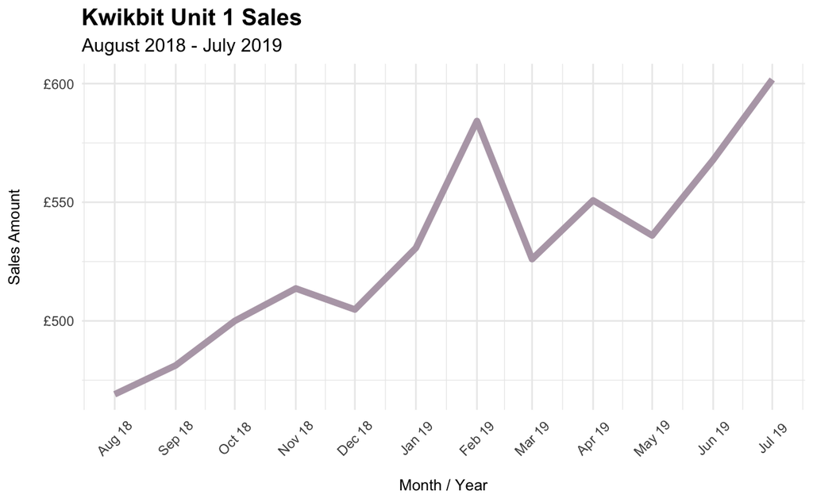

```r
qb_monthly_sales %>%
  filter(cashflow == "Kwikbit Unit 1 Sales") %>%
  ggplot(aes(x = date, y = amount)) +
  geom_line(colour = col_scheme[3], linewidth = 2) +
  theme_minimal() +
  scale_y_continuous(labels = scales::dollar_format(prefix = "£")) +
  scale_x_date(date_labels = "%b %y", date_breaks = "1 month") +
  labs(
    x = "\nMonth / Year",
    y = "Sales Amount\n",
    title = "Kwikbit Unit 1 Sales",
    fill = "Product:",
    subtitle = "August 2018 - July 2019"
  ) +
  theme(plot.title = element_text(size = 15, face = "bold"),
        plot.subtitle = element_text(size = 12),
        axis.title.x = element_text(size = 10),
        axis.title.y = element_text(size = 10),
        axis.text.x = element_text(angle = 45, vjust = 0.5))
```

### Q3 Revised

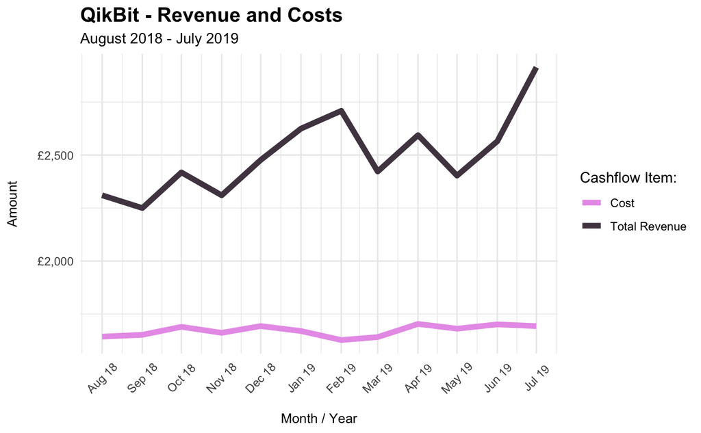

```r
qb_monthly_sales %>%
  filter(cashflow != "Kwikbit Unit 1 Sales") %>%
  ggplot(aes(x = date, y = amount, colour = cashflow)) +
  geom_line(linewidth = 2) +
  scale_x_date(date_labels = "%b %y", date_breaks = "1 month") +
  scale_y_continuous(labels = scales::dollar_format(prefix = "£")) +
  theme_minimal() +
  theme(plot.title = element_text(size = 15, face = "bold"),
        axis.title.x = element_text(size = 10),
        axis.title.y = element_text(size = 10),
        axis.text.x = element_text(angle = 45, vjust = 0.5)) +
  labs(
    x = "\nMonth / Year",
    y = "Amount\n",
    title = "QikBit - Revenue and Costs",
    subtitle = "August 2018 - July 2019",
    colour = "Cashflow Item:"
  ) +
  scale_color_manual(values = col_scheme)
```

### Q4 Revised

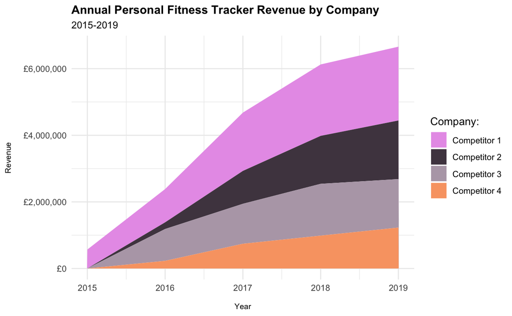

```r
qb_competitors %>%
  ggplot(aes(x = year, y = revenue, fill = company)) +
  geom_area() +
  theme_minimal() +
  scale_y_continuous(labels = scales::dollar_format(prefix = "£")) +
  theme(plot.title = element_text(size = 12, face = "bold"),
        plot.subtitle = element_text(size = 10),
        axis.title.x = element_text(size = 8),
        axis.title.y = element_text(size = 8)) +
  labs(
    x = "\nYear",
    y = "Revenue\n",
    title = "Annual Personal Fitness Tracker Revenue by Company",
    subtitle = "2015-2019",
    fill = "Company:"
  ) +
  scale_fill_manual(values = col_scheme)
```

### Q5 Revised

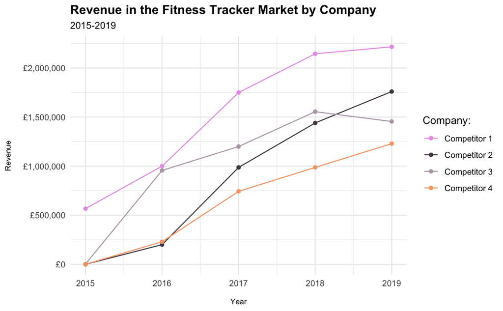

```r
qb_competitors %>%
  ggplot(aes(x = year, y = revenue, colour = company)) +
  geom_line() +
  geom_point() +
  theme_minimal() +
  scale_y_continuous(labels = scales::dollar_format(prefix = "£")) +
  theme(plot.title = element_text(size = 13, face = "bold"),
        plot.subtitle = element_text(size = 10),
        axis.title.x = element_text(size = 8),
        axis.title.y = element_text(size = 8)) +
  labs(
    x = "\nYear",
    y = "Revenue\n",
    title = "Revenue in the Fitness Tracker Market by Company",
    subtitle = "2015-2019",
    colour = "Company:"
  ) +
    scale_color_manual(values = col_scheme)
```

### Q6 Revised

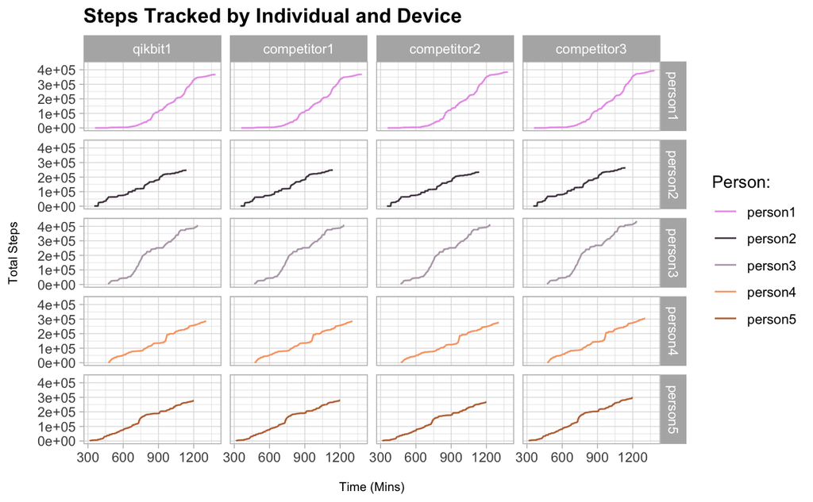

```r
qb_device_data_updated %>%
  group_by(id) %>%
  ggplot(aes(x = total_time_mins, y = rolling_steps_count, colour = id)) +
  geom_line() +
  theme_light() +
  facet_grid(id ~ device) +
  theme(plot.title = element_text(size = 13, face = "bold"),
        axis.title.x = element_text(size = 8),
        axis.title.y = element_text(size = 8)) +
  labs(
    x = "\nTime (Mins)",
    y = "Total Steps\n",
    title = "Steps Tracked by Individual and Device",
    colour = "Person:"
  ) +
  scale_color_manual(values = col_scheme)
```